# 머신러닝과 딥러닝 개요

## Artificial Intelligence

### Computer를 이용한 문제 해결

- 최초의 컴퓨터
  - ABACUS : 주판
- 전자계산기
  - 논리 회로 : AND, OR, NOT
  - 가산기(Adder)
    - XOR, AND
    - 더하기 연산
    - CPU
  - flip-flop(Latch) :
    - NOR x 2
    - 1bit 상태 기억
    - Memory
- 컴퓨터는 오직 계산만 가능

  > *컴퓨터는 사고(생각)할 수 없다*

#### Adder

- XOR , AND
- Sum : 누적, Carry : 올림 수

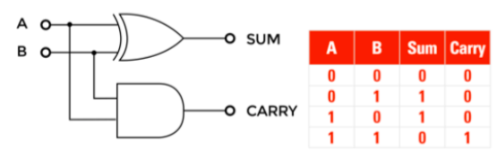

#### Flip-Flop(Ratch)

- NOR(NOT OR) x 2 또는 NAND x 2
  - S=0, R=0 : Q 값 상태유지, $Q_t = Q_{t+1}$
  - S=0, R=1 : Q의 현재 상태와 무관하게 Q는 0, $Q_{t+1} = 0$,
  - S=1, R=0 : Q의 현재 상태와 무관하게 Q=1, $Q_{t+1} = 1$
  - S=1, R=1 : 불능..

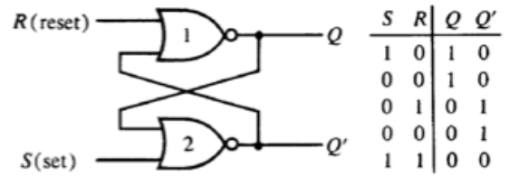

### Computer를 이용한 문제 해결

- HardWare
  - 수 많은 스위치(Switch)
  - 반도체로 집적한 논리회로
  - CPU(Central Processing Unit)
    - 프로그램의 명령 해석 및 실행
    - 클럭(Clock) : 초당 연산 속도
      - 예) 2.4GHz, 1초당 24억번의 연산 수행
    - 코어(Core) : 동시에 수행할 장치의 수
      - 예) Dual Core = 2CPU, Quad Core = 4CPU
  - Memory
    - 데이타 기억
    - 책상, 손으로 비유
- Software
  - 스위치를 조작하기 위한 명령
  - 동작하기 원하는 스위치 상태
- Programming
  - Software를 만드는 과정

### 프로그래밍 패러다임

- 알고리즘 기반 프로그래밍
  - 지식공학, 합리주의
  - 마빈민스키, 노암 초스키, 데카르트
  - 입력 : 데이타 + 프로그램(알고리즘)
  - 출력 : 결과 값
- 데이타 기반 프로그래밍
  - 기계학습, 경험주의
  - 앤드류 응, 페드로 도밍고스, 데이비드 흄
  - 입력 : 데이타 + 결과 값
  - 출력 : 프로그램(알고리즘)

### 수학 문제를 푸는 2가지 방법

- 등식의 성질을 이용하여 다음 방정식의 $x$를 구하시오.
  - $\displaystyle \frac{x-4}{3} = 2 $

#### 수학 문제 푸는 방법 1

##### 방정식 풀이

- $\displaystyle \frac{x-4}{3}\times3 = 2\times3 $
- $\displaystyle x-4= 6 $
- $\displaystyle x-4+4= 6+4 $
- $\displaystyle x= 10 $

#### 수학 문제 푸는 방법 2

###### $x$의 값을 바꾸면서 정답에 가까운 방향으로 시도 반복

- $\displaystyle x=1: \frac{1-4}{3} = -1, $, 차이: 3
- $\displaystyle x=-1: \frac{-1-4}{3} = -1.6666$, 차이: 3.6666
- $\displaystyle x=2: \frac{2-4}{3} = -0.6666$, 차이: 2.6666
- $\displaystyle x=3: \frac{3-4}{3} = -0.3333$, 차이: 2.3333
- $\displaystyle x=5: \frac{5-4}{3} = 0.3333$, 차이: 1.6666
- $\displaystyle x=9: \frac{9-4}{3} = 1.6666$, 차이: 0.3333
- $\displaystyle x=10: \frac{10-4}{3} = 2$, *차이: 0*
- $\displaystyle x=11: \frac{10-4}{3} = 2.3333$, 차이: 0.3333

### 인공지능

- 인간에 의해서 생성된 기계로 부터의 지능
- 강인공지능(String AI)
  - 존 매카시, 다트머스 회의
    - 기계를 인간 행동의 지식에서와 같이 행동하게 만드는 것
  - 인간의 사고와 같이 컴퓨터가 행동하고 사고하는 지능
- 약인공지능(Weak AI)
  - 특정 부분에 한해 지능적인 행동으로 보이는 것
  - 알파고(딥마인드)
- 구현 기술
  - 전문가 시스템(Expert System)
  - 퍼지 이론(Fuzzy Theory)
  - 기계학습(Machine Learning)
  - 인공 신경망(Neural Network)
  - 유전 알고리즘(Genetic Algorithm)
  - 로보틱스(Robotics)

### 인공지능의 역사

- 1956년 미국 다트머스회의
  - 존 메카시, 마빈 민스키, 클로드 섀넌 용어 처음 사용
- 1950 ~ 1970 : 심볼릭 AI
  - 충분히 많은 명시적인 규칙으로 인간 수준 지능 생성하려는 시도
  - 계산 기능, 논리 쳬계 한계
  - 첫 번째 겨울
- 1980 전문가 시스템(Expert System)
  - 심볼릭 AI의 새로운 버전으로 호황
    - 체스 게임 같은 잘 정의된 논리적 문제 적합
    - 이미지 분류, 음성인식 등 불문명한 문제 해결에 어려움
  - 머신러닝
    - 새로운 방법 등장
    - 데이타 부족, 알고리즘 한계
  - 두 번재 겨울
- 2010 ~ 딥러닝
  - 제프리 힌트(Geoffrey Hinton, 토론토 대학)
  - 구글 딥마인드, 알파고

## Machine Learning & Deep Learning

### 인공지능과 머신러닝 그리고 딥러닝

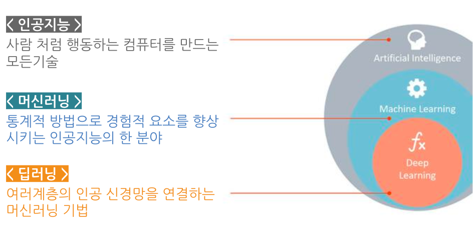

### 머신러닝 역사

- 확률적 모델링(Probabilistic Modeling)
  - 통계학 이론을 데이타 분석에 응용
  - 컴퓨터 등장 전 부터 사용
  - 나이브 베이즈(Naive Bayes)
  - 로지스틱 회귀(Logistic Regression)
- 초창기 신경망
  - 1950년대 연구 시작, 대규모 신경망 훈련 방법 발견 실패
  - 1980년대 역전파(Back Propagation) 알고리즘으로 재발견
  - 1989년 벨 연구소, 얀 르쿤(Yann Lecun)
    - CNN과 역전파를 사용해서 손글씨 분류 성공
    - LeNet, 1990년대 미국 우편 서비스에 실 사용
- 커널 방법
  - 초창기 신경망에 비해 빠르고 효과적, 가장 인기 있는 알고리즘
  - 1990년대 SVM(Support Vector Machine)
    - 벨 연구소 블라드미르 바프닉, 코리나 코르테스 개발
- 결정트리, 랜덤 포레스트, 그래디언트 부스팅 머신
  - 2000년대 큰 관심
  - 2010년 이후 딥러닝 다음으로 가장 인기 있는 기법

### 머신러닝 알고리즘

- 학습 방법
  - 지도학습
    - 레이블(정답)이 있는 데이타
    - 분류(Classification) 이산적
    - 회귀(Regression) 연속적
    - 평가(Estimation) 확률적
  - 비지도 학습
    - 레이블 없거나 고려하지 않음
    - 데이터에 내재된 패턴, 특성, 구조를 발견
    - 군집(Clustering)
    - 차원 축소(PCA)
  - 강화 학습
    - 결과에 따른 평가가 시간이 지나서 얻어짐
    - 여러행위 중에 최종 결과에 영향을 준것을 찾는다.
    - 시스템의 동작이 적절성에 대한 피드백이 있는 학습

### 머신러닝 알고리즘

- 모델 표현 방법
  - 의사결정 트리
    - 기호 주의
  - 신경망 기반
    - 연결주의, 역전파
  - kNN, SVM
    - 유추주의, 기하학적 거리
  - Naive Beyes
    - 확률 통계, 추론
  - 유전 알고리즘
    - 진화주의
  - 앙상블
    - 조합

### 딥러닝 역사

- Backpropagation 알고리즘 재발견
  - 1974, 1982 by Paul Werbos
  - 1986 Hinton
  - 1995 Big problem
  - 역전파는 MLP의 깊이가 깊어지면 동작하지 않는다.
- CIFAR(Canadian Institute for Advanced Research)
  - 2006 제프리 힌튼(Hinton 토론토 대학)
  - 2007 요슈아 벤지오(Bengio, 몬트리올 대학)
    - 깊은 MLP도 학습이 가능하다.
  - CNN 얀 르쿤(뉴욕 대학)
  - 댄 크리슨(Ciresan, IDSIA 스위스) 2011 학술 이미지 분류 대회 우승
  - Deep Learning 재명명

### 딥러닝의 필요성

- XOR 문제 해결 불가능
- 선형분류로 해결 불능

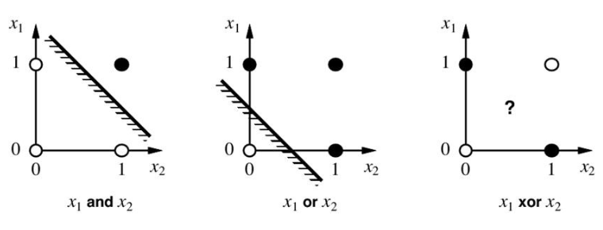

### 딥러닝 불가론

- 신경망을 여러개층으로 연결 한것
- 초창기 신경망에서는 역전파 알고리즘 한계
- 1969 "MLP(다계층 인공 신경망)의 학습은 불가능하다"
  - Perceptron by Marvin Minsky(마빈 민스키), MIT AI Lab

    > "No one on earth had found a viable way to train"

[figure not shown]

### 딥러닝 재명명

- Backpropagation 알고리즘 재발견
  - 1974, 1982 by Paul Werbos
  - 1986 Hinton
  - 1995 Big problem
  - 역전파는 MLP의 깊이가 깊어지면 동작하지 않는다.
- CIFAR(Canadian Institute for Advanced Research)
  - 2006, 2007 Hinton, Bengio
    - 깊은 MLP도 학습이 가능하다.
  - Deep Learning 재명명

### 딥러닝 새시작

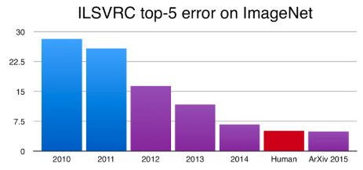

### 딥러닝 동향

- 하드웨어
  - 1990 ~ 2010 CPU 속도 5000배 개선
  - GPU, CUDA 지원
  - TPU(Tensor Processing Unit) by Google
- 데이터 셋과 벤치마크
  - 딥러닝 = 산업혁명의 증기기관
  - 데이터 셋 = 석유(연료)
  - 대학과 연구 기관의 정제된 데이타 셋 제공
  - 각종 경영 대회
- 알고리즘
  - 새로운 알고리즘 개발
  - 활성화 함수(Activation Function)
  - 가중치 초기화(Weight Initialization)
  - 옵티마이저(RMSProp, Adam 등)

## Development Environment Installation

### 필수 소프트웨어

- Python 3.4+
  - http://www.python.org
- NumPy
  - http://www.numpy.org/
- SciPy
  - https://www.scipy.org/
- Scikit-learn
  - https://scikit-learn.org/stable/
- Tensorflow
  - https://www.tensorflow.org/
- Keras
  - https://keras.io/
- Jupyter Notebook
  - https://jupyter.org/
- MatPlotLib
  - https://matplotlib.org/
- Pandas
  - https://pandas.pydata.org/

### Python 설치

- http://www.python.org/downloads/
  - Yes : ver 3.6+
  - No : ver 2.x

[figure not shown]

### Python 설치

- Install on PC
- Default Path
- Enable "Add Python 3.x to Path" Option

[figure not shown]

### Python 설치

- Hello World
- REPL(Read-Eval-Print-Loop)
  - Open Windows command console
  - Execute 'python' command
  - opened python shell prompt
  - execute 'print("Hello World")'
  - 'exit()' to exit
- Source Code
  - make a file named 'hello_world.py'
  - edit content below *

    ```
    print("Hello World!!")
    ```

  - execute command
    - `python hello_world.py`

### VirtualEnv 설치

- 설치
  - `pip install -U virtualenv`
- 생성 (ml : 생성할 이름)
  - `virtualenv ml`
- 활성화
  - `cd ml`
  - `call .\Scripts\activate`
- 비활성화
  - `deactivate`

### NumPy 설치

- 설치
  - `pip install -U numpy`
- 확인

```python
import numpy
numpy.__version__
```

```
'1.16.2'
```

### SciPy 설치

- 설치
  - `pip install -U scipy`
- 확인

```python
import scipy
scipy.__version__
```

```
'1.2.1'
```

### scikit-learn 설치

- 설치
  - `pip install -U scikit-learn`
- 확인

```python
import sklearn
sklearn.__version__
```

```
'0.20.3'
```

### Tensorflow 설치

- 설치
  - `pip install -U tensorflow` : CPU version
  - `pip install -U tensorflow-gpu` : GPU version
- 설치 확인

```python
import tensorflow
tensorflow.__version__
```

```
'1.13.1'
```

### Keras 설치

- 설치
  - `pip install -U keras`
- 설치 확인

```python
import keras
keras.__version__
```

```
'2.2.4'
```

### MatPlotLib 설치

- 설치
  - `pip install -U matplotlib`
- 설치 확인

```python
import matplotlib
matplotlib.__version__
```

```
'3.0.3'
```

### Pandas 설치

- 설치
  - `pip install -U pandas`
- 설치 확인

```python
import pandas
pandas.__version__
```

```
'0.24.1'
```

### Jupyter Notebook 설치

- 설치
  - `pip install -U jupyter`
- 실행
  - `jupyter notebook password`
  - `Enter new`

### Jupyter Notebook 커널 설치

- 설치
  - `pip install -U ipykernel`
- 커널 추가
  - `python -m ipykernel install --user --name ml --display-name "Python(ml)"`
- 실행
  - `jupyter notebook`

#### Jupyter Notebook 실행

[figure not shown]

### 설치한 모든 모듈 버전 확인

```python
import numpy
import scipy
import matplotlib
import pandas
import sklearn
import tensorflow
import keras

print('numpy : %s'%numpy.__version__)
print('scipy : %s'%scipy.__version__)
print('matplotlib : %s'%matplotlib.__version__)
print('pandas : %s'%pandas.__version__)
print('sklearn : %s'%sklearn.__version__)
print('tensorflow : %s'%tensorflow.__version__)
print('keras : %s'% keras.__version__)
```

```
numpy : 1.16.2
scipy : 1.2.1
matplotlib : 3.0.3
pandas : 0.24.1
sklearn : 0.20.3
tensorflow : 1.13.1
keras : 2.2.4
```

# 추가 모듈 설치

- opencv
  - `pip install opencv-contrib-python`
- pydot
  - `pip install pydot`
- grphviz
  - 실행파일 설치 : https://graphviz.gitlab.io/download/
  - `pip install graphviz`

```python
import cv2
import pydot
import graphviz

print('cv2:', cv2.__version__)
print('pydot:', pydot.__version__)
print('graphviz:', graphviz.__version__)
```

```
cv2: 4.0.0
pydot: 1.4.1
graphviz: 0.10.1
```